# Instalando y usando paquetes

# 1. Los Paquetes

Los paquetes en R son colecciones de funciones y datos generados por la comunidad. Algunos vienen por defecto con el entorno de R, mientras que otros hay que instalarlos desde repositorios. Los principales repositorios son:

- CRAN https://cran.r-project.org/ el repositorio oficial de R.
- Bioconductor https://www.bioconductor.org/, que aloja paquetes relacionados con la bioinformática.
- Github https://github.com/ no está relacionado con R específicamente, pero es muy popular para proyectos de código abierto.

Podemos ver los paquetes cargados en el entorno con el comando `search()`:

```r
search()
```

```
## [1] ".GlobalEnv"        "package:stats"     "package:graphics"
## [4] "package:grDevices" "package:utils"     "package:datasets"
## [7] "package:methods"   "Autoloads"         "package:base"
```

Los paquetes que vemos en este momento son los que están cargados por defecto. En el paquete `datasets` hay conjuntos de datos de ejemplo que se pueden cargar con el comando `data()`:

```r
data(iris)
iris
```

```
##     Sepal.Length Sepal.Width Petal.Length Petal.Width    Species
## 1            5.1         3.5          1.4         0.2     setosa
## 2            4.9         3.0          1.4         0.2     setosa
## 3            4.7         3.2          1.3         0.2     setosa
## 4            4.6         3.1          1.5         0.2     setosa
## 5            5.0         3.6          1.4         0.2     setosa
## 6            5.4         3.9          1.7         0.4     setosa
## 7            4.6         3.4          1.4         0.3     setosa
## 8            5.0         3.4          1.5         0.2     setosa
## 9            4.4         2.9          1.4         0.2     setosa
## 10           4.9         3.1          1.5         0.1     setosa
## 11           5.4         3.7          1.5         0.2     setosa
## 12           4.8         3.4          1.6         0.2     setosa
## 13           4.8         3.0          1.4         0.1     setosa
## 14           4.3         3.0          1.1         0.1     setosa
```

[output cut: 136 more lines]

Podemos obtener ayuda sobre cualquier comando con `?` (observa el panel inferior derecho)

```r
?data
```

```
## starting httpd help server ... done
```

Con el operador `$` podemos acceder a cada una de las variables del conjunto de datos Iris:

```r
iris$Sepal.Width
```

```
##   [1] 3.5 3.0 3.2 3.1 3.6 3.9 3.4 3.4 2.9 3.1 3.7 3.4 3.0 3.0 4.0 4.4 3.9 3.5
##  [19] 3.8 3.8 3.4 3.7 3.6 3.3 3.4 3.0 3.4 3.5 3.4 3.2 3.1 3.4 4.1 4.2 3.1 3.2
##  [37] 3.5 3.6 3.0 3.4 3.5 2.3 3.2 3.5 3.8 3.0 3.8 3.2 3.7 3.3 3.2 3.2 3.1 2.3
##  [55] 2.8 2.8 3.3 2.4 2.9 2.7 2.0 3.0 2.2 2.9 2.9 3.1 3.0 2.7 2.2 2.5 3.2 2.8
##  [73] 2.5 2.8 2.9 3.0 2.8 3.0 2.9 2.6 2.4 2.4 2.7 2.7 3.0 3.4 3.1 2.3 3.0 2.5
##  [91] 2.6 3.0 2.6 2.3 2.7 3.0 2.9 2.9 2.5 2.8 3.3 2.7 3.0 2.9 3.0 3.0 2.5 2.9
## [109] 2.5 3.6 3.2 2.7 3.0 2.5 2.8 3.2 3.0 3.8 2.6 2.2 3.2 2.8 2.8 2.7 3.3 3.2
## [127] 2.8 3.0 2.8 3.0 2.8 3.8 2.8 2.8 2.6 3.0 3.4 3.1 3.0 3.1 3.1 3.1 2.7 3.2
## [145] 3.3 3.0 2.5 3.0 3.4 3.0
```

```r
iris$Sepal.Length
```

```
##   [1] 5.1 4.9 4.7 4.6 5.0 5.4 4.6 5.0 4.4 4.9 5.4 4.8 4.8 4.3 5.8 5.7 5.4 5.1
##  [19] 5.7 5.1 5.4 5.1 4.6 5.1 4.8 5.0 5.0 5.2 5.2 4.7 4.8 5.4 5.2 5.5 4.9 5.0
##  [37] 5.5 4.9 4.4 5.1 5.0 4.5 4.4 5.0 5.1 4.8 5.1 4.6 5.3 5.0 7.0 6.4 6.9 5.5
##  [55] 6.5 5.7 6.3 4.9 6.6 5.2 5.0 5.9 6.0 6.1 5.6 6.7 5.6 5.8 6.2 5.6 5.9 6.1
##  [73] 6.3 6.1 6.4 6.6 6.8 6.7 6.0 5.7 5.5 5.5 5.8 6.0 5.4 6.0 6.7 6.3 5.6 5.5
##  [91] 5.5 6.1 5.8 5.0 5.6 5.7 5.7 6.2 5.1 5.7 6.3 5.8 7.1 6.3 6.5 7.6 4.9 7.3
## [109] 6.7 7.2 6.5 6.4 6.8 5.7 5.8 6.4 6.5 7.7 7.7 6.0 6.9 5.6 7.7 6.3 6.7 7.2
## [127] 6.2 6.1 6.4 7.2 7.4 7.9 6.4 6.3 6.1 7.7 6.3 6.4 6.0 6.9 6.7 6.9 5.8 6.8
## [145] 6.7 6.7 6.3 6.5 6.2 5.9
```

La función `summary()` muestra un resumen de un conjunto de datos:

```r
summary(iris)
```

```
##   Sepal.Length    Sepal.Width     Petal.Length    Petal.Width
##  Min.   :4.300   Min.   :2.000   Min.   :1.000   Min.   :0.100
##  1st Qu.:5.100   1st Qu.:2.800   1st Qu.:1.600   1st Qu.:0.300
##  Median :5.800   Median :3.000   Median :4.350   Median :1.300
##  Mean   :5.843   Mean   :3.057   Mean   :3.758   Mean   :1.199
##  3rd Qu.:6.400   3rd Qu.:3.300   3rd Qu.:5.100   3rd Qu.:1.800
##  Max.   :7.900   Max.   :4.400   Max.   :6.900   Max.   :2.500
##        Species
##  setosa    :50
##  versicolor:50
##  virginica :50
##
##
##
```

```r
summary(iris$Sepal.Width)
```

```
##    Min. 1st Qu.  Median    Mean 3rd Qu.    Max.
##   2.000   2.800   3.000   3.057   3.300   4.400
```

Busca en la ayuda como configurar el número de cifras significativas que muestra la función `summary()` y cámbialo para que sólo muestre un decimal:

```r
summary(iris, digits = 2)
```

```
##   Sepal.Length  Sepal.Width   Petal.Length  Petal.Width        Species
##  Min.   :4.3   Min.   :2.0   Min.   :1.0   Min.   :0.1   setosa    :50
##  1st Qu.:5.1   1st Qu.:2.8   1st Qu.:1.6   1st Qu.:0.3   versicolor:50
##  Median :5.8   Median :3.0   Median :4.3   Median :1.3   virginica :50
##  Mean   :5.8   Mean   :3.1   Mean   :3.8   Mean   :1.2
##  3rd Qu.:6.4   3rd Qu.:3.3   3rd Qu.:5.1   3rd Qu.:1.8
##  Max.   :7.9   Max.   :4.4   Max.   :6.9   Max.   :2.5
```

## 1.1 Cargando un paquete en el entorno

La función ´bkde()´ calcula una estimación de la densidad de la distribución de un conjunto de datos. Es una función de un paquete que no está cargado por defecto. Si la intentamos invocar no va a funcionar:

```r
#estimacion_densidad = bkde(iris$Sepal.Width)
```

Podemos buscar en Que paquete esta con el comando `??`

```r
??bkde
```

En la ayuda podemos ver que está en el paquete `KernSmooth`. Para cargar un paquete empleamos la función `library()` y el nombre del paquete, que puede ir entre comillas o sin comillas:

```r
library(KernSmooth)
```

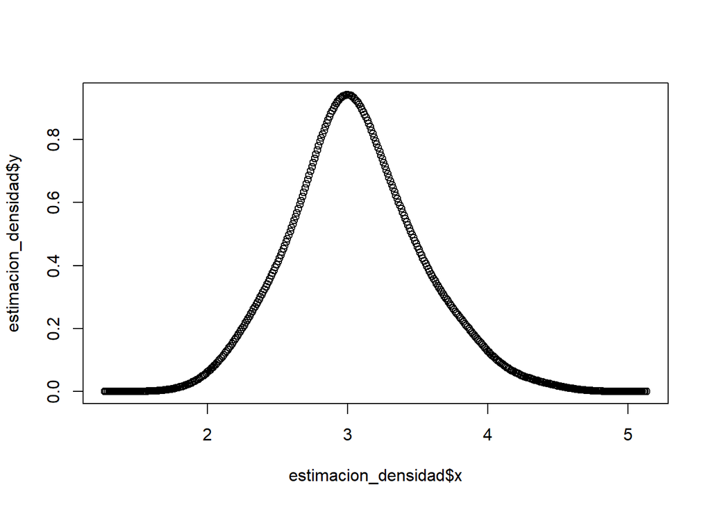

```r
estimacion_densidad = bkde(iris$Sepal.Width)
plot(estimacion_densidad)
```

## 1.2 Instalando un paquete

El paquete `dplyr` contiene funciones útiles para manipular datos. Pero no está instalado por defecto, sino que hay que instalarlo (Para ejecutar el comando tendrás que quitar el comentario. Pero no podrás compilar todo el archivo .Rmd si no está comentado. La instalación de paquetes es algo que sólo es necesario realizar una vez, y no es algo que se deba hacer en Markdow):

```r
#install.packages("dplyr")
```

Una vez instalado, hay que cargarlo:

```r
library(dplyr)
```

Ahora podemos usar sus funciones. Seleccionamos solo las flores Virginica con la función `filter()`

```r
filter(iris,Species=="virginica")
```

```
##    Sepal.Length Sepal.Width Petal.Length Petal.Width   Species
## 1           6.3         3.3          6.0         2.5 virginica
## 2           5.8         2.7          5.1         1.9 virginica
## 3           7.1         3.0          5.9         2.1 virginica
## 4           6.3         2.9          5.6         1.8 virginica
## 5           6.5         3.0          5.8         2.2 virginica
## 6           7.6         3.0          6.6         2.1 virginica
## 7           4.9         2.5          4.5         1.7 virginica
## 8           7.3         2.9          6.3         1.8 virginica
## 9           6.7         2.5          5.8         1.8 virginica
## 10          7.2         3.6          6.1         2.5 virginica
## 11          6.5         3.2          5.1         2.0 virginica
## 12          6.4         2.7          5.3         1.9 virginica
## 13          6.8         3.0          5.5         2.1 virginica
## 14          5.7         2.5          5.0         2.0 virginica
```

[output cut: 36 more lines]

```r
filter(iris,Species=="virginica" & Sepal.Length<6 & Sepal.Width<=2.7)
```

```
##   Sepal.Length Sepal.Width Petal.Length Petal.Width   Species
## 1          5.8         2.7          5.1         1.9 virginica
## 2          4.9         2.5          4.5         1.7 virginica
## 3          5.7         2.5          5.0         2.0 virginica
## 4          5.8         2.7          5.1         1.9 virginica
```

Podemos desinstalar paquetes con el comando remove.packages(). Ojo que está comentado; puedes probar a descomentarlo y ejecutarlo.

```r
#remove.packages("dplyr")
```